# Lab 3: Mine Crafting

As with previous labs, be sure to submit only the `lab3.ipynb` and `lab3.html` version of the lab in your github `Lab3` folder. No more, and no less.

## Introduction

Imagine you are a scientist for a mining company that operates a vertical mine at the Earth's equator. This is one of the deepest mines on Earth; it's roughly 4 km to the bottom of the shaft. Your boss proposes to measure the vertical depth of the shaft by dropping a 1 kg test mass and accurately measuring the time to hit the bottom.

You will be guided in your investigations below and submit your report in the form of this notebook. Be sure to be quantitative in nature, produce highly polished plots, with appropriate titles, units, etc.

A table of relevant physical constants is below. Good luck!

| Quantity | Value |
| --- | --- |
| Gravitational Constant ($G$) | $6.6743 \times 10^{-11}$ m$^3$/kg/s$^2$ |
| Gravitational Acceleration ($g_o$) | 9.81 m/s$^2$ (approximate) |
| Mass of the Earth ($M_{\oplus}$) | $5.972 \times 10^{24}$ kg |
| Mass of the Moon ($M_{m}$) | $7.35 \times 10^{22}$ kg |
| Radius of the Earth ($R_{\oplus}$) | 6378.1 km |
| Radius of the Moon ($R_{m}$) | 1738.1 km |
| Earth's Rotation Rate at the Equator | $7.272 \times 10^{-5} $ rad/s |

```python
import math
import numpy as np
import matplotlib.pyplot as plt
from scipy.integrate import solve_ivp
from scipy.integrate import quad
```

```python
G  = 6.6743 * 10**-11 # m^3/kg/s^2
g  = 9.81             # m/s^2
Me = 5.972  * 10**24  # kg
Mm = 7.35   * 10**22  # kg
Re = 6378100          # m
Rm = 1738100          # m
RR = 7.272  * 10**-5  # rad/s
```

## Part 1: The Ideal Case

In this section and the following sections, we calculate the time for the 1 kg test mass to reach the bottom of the mineshaft under a series of increasingly complex assumptions. Remember that a projectile experiencing a constant gravitational force, plus a drag force, obeys the following second order differential equation:

$$ \frac{d^2y}{dt^2} = -g + \alpha \left| \frac{dy}{dt} \right|^{\gamma} \tag{1} $$

where $t$ is time, $y$ is the height, $g$ is the gravitational acceleration, $\alpha$ is the drag coefficient, and $\gamma$ is the speed dependence of the drag. For example, for $\gamma=2$, the drag force grows proportionally to the speed *squared*. **Hint**: pay particular attention to the sign conventions in your implementation! The drag, by definition, should *oppose* the direction of motion.

1. First, make a simple calculation of how long a test mass would take to reach the bottom of the 4km shaft assuming no drag. This is the simple free-fall algebraic expression you know from PHYS 171.
2. Next, reduce (1) into a *system* of coupled first order differential equations by setting the velocity $v = dy/dt$.
3. Numerically solve (1) using `solve_ivp` assuming $\alpha=0$. Plot the position and velocity as a function of time.  
   Draw a horizontal dashed line at the depth of the bottom of the shaft, to make it easy to see. Make the plot look nice, including displaying the position on the left axes, and plotting the velocity on a second right axis, using matplotlib `twinx` capability.  
   In your notebook, label this figure clearly as **Figure 1**.
4. Using the `events` detection capability of `solve_ivp`, calculate the time at which the mass hits the bottom of the shaft in the case of zero drag ($\alpha=0$). Compare this to your analytic calculation and discuss any differences you might see.

```python
### 1
# Define constants
m = 1      # kg
dy = -4000 # m
a = -g     # Defines y as negative

# Rewrite and solve kinematic eq : dy = (1/2) * a * t**2
kinem_t = np.sqrt(2*dy/a)
print(f'{kinem_t:.4f} seconds')
```

```
28.5569 seconds
```

```python
### 2
# Define functions : dx/dt = v  and  dv/dt = -g + alpha*|v|^gamma
def fall_ideal(t,s):
    """ A function which calculates the velocity and position of an object using acceleration and velocity functions

    args:
        t (array): The time when an object is at a certain acceleration and velocity in seconds
        s (array): The velocity and acceleration of an object in m/s and m/s^2 respectively

    Returns:
        array : The resulting position and velocity arrays of the mass in m and m/s respectively
    """
    # s  = [y  vy ]
    # dt = [dy dvy]
    dt = np.zeros(2)
    dt[0] = s[1]
    dt[1] = -g + alpha*(np.abs(s[1]))**gamma
    return dt
```

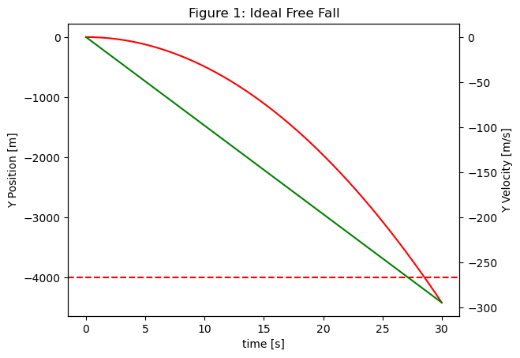

```python
### 3
# Set time frame and initial values
span = (0,30)
time = np.linspace(*span,50)
y0 = [0,0]
s0 = [*y0,0,0]

# Set constant values
alpha = 0
gamma = 1 # Doesn't matter...

# Solve IVP
sol = solve_ivp(fun=fall_ideal,t_span=span,y0=y0,t_eval=time)

# Extract time, position, velocity
sol_t = sol.t
sol_y = sol.y[0]
sol_vy = sol.y[1]

# Create figure and add second ax by twin x
fig1,ax1a = plt.subplots()
ax1b = ax1a.twinx()

# Plot position, velocity, and bottom of hole
ax1a.plot(sol_t,sol_y,label='Position',color='red')
ax1b.plot(sol_t,sol_vy,label='Velocity',color='green')
ax1a.axhline(-4000,color='red',ls='--')

# Label everything
ax1a.set_xlabel('time [s]')
ax1a.set_ylabel('Y Position [m]')
ax1b.set_ylabel('Y Velocity [m/s]')
ax1a.set_title('Figure 1: Ideal Free Fall');
```

```python
### 4
# Create an event requirement
def hit(t,s):
    """ A function which returns the difference between the object's current position and the bottom of the shaft

    args:
        t (array): The time when an object is at a certain acceleration and velocity in seconds
        s (array): The velocity and acceleration of an object in m/s and m/s^2 respectively

    Returns:
        array : The distance of the mass from the bottom of the shaft in meters
    """
    return s[0]+4000

# Solve IVP with an event
solevent = solve_ivp(fun=fall_ideal,t_span=span,y0=y0,t_eval=time,events=hit)

# Extract time of event occurance
solevent_t = solevent.t_events[0]

# Print solutions
print(f'Analytic solution: {kinem_t:.8f} seconds')
print(f'SolveIVP solution: {solevent_t[0]:.8f} seconds')
```

```
Analytic solution: 28.55686246 seconds
SolveIVP solution: 28.55686246 seconds
```

There is no difference between the analytic and solve_ivp solutions. Due to the simplicity of the ideal case, the functions given to IVP integrate into the same kinematic function.

## Part 2: Including Drag and a Variable g

In practice, we cannot ignore drag, and we should also not assume that $g$ is a constant. If you approximate that the mass of the Earth is distributed homogenously (which it is not!), then the gravitational constant $g$ will depend on your distance $r$ from the center of the Earth in a simple linear way:

$$ g(r) = g_o \left( \frac{r}{R_{\oplus}} \right) \tag{2} $$

where $g_o$ is the gravity at the surface, and $R_{\oplus}$ is the radius of the Earth.

1. Make a new plot that shows the velocity and position as a function of  
   time assuming $g(y)$. Be careful with coordinate systems! The test mass' position should be at the Earth radius at $t=0$, and falling down. But for plotting purposes, it will be useful to plot the height above the bottom of the shaft.  
   In your notebook, label this figure clearly as **Figure 2**.
2. What effect does incorporating a height-dependent $g$ have on the fall time? Explain.
3. Now, turn on drag, and replot the position and velocity. For most things, $\gamma=2$ is a good assumption. How can you calibrate the value of $\alpha$? Think about what we did in Lecture 15/16, where we assumed a sky-diver's terminal speed was 50 m/s. You should assume the same of the test mass. What affect does including drag have on the fall time?

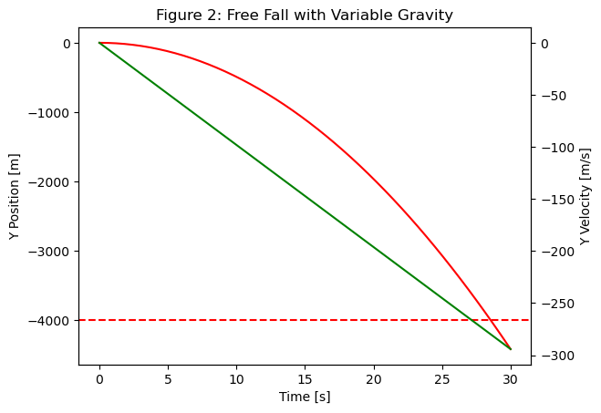

```python
### 1
# Rewrite fall_ideal to include a variable g
def fall_grav(t,s):
    """ A function which calculates the velocity and position of an object using acceleration and velocity functions while assuming a homogeneous variable gravity

    args:
        t (array): The time when an object is at a certain acceleration and velocity in seconds
        s (array): The velocity and acceleration of an object in m/s and m/s^2 respectively

    Returns:
        array : The resulting position and velocity arrays of the mass in m and m/s respectively
    """
    # s  = [y  vy ]
    # dt = [dy dvy]
    dt = np.zeros(2)
    grav = g*((Re+s[0])/Re)
    dt[0] = s[1]
    dt[1] = -grav + alpha*(np.abs(s[1]))**gamma
    return dt

# Solve IVP
solgrav = solve_ivp(fun=fall_grav,t_span=span,y0=y0,t_eval=time)

# Extract time, position, velocity
solgrav_t = solgrav.t
solgrav_y = solgrav.y[0]
solgrav_vy = solgrav.y[1]

# Create figure and twin ax2a and ax2b
fig2,ax2a = plt.subplots()
ax2b = ax2a.twinx()

# Plot position, velocity, and bottom of hole
ax2a.plot(solgrav_t,solgrav_y,label='Position',color='red')
ax2b.plot(solgrav_t,solgrav_vy,label='Velocity',color='green')
ax2a.axhline(-4000,color='red',ls='--')

# Label everything
ax2a.set_xlabel('Time [s]')
ax2a.set_ylabel('Y Position [m]')
ax2b.set_ylabel('Y Velocity [m/s]')
ax2a.set_title('Figure 2: Free Fall with Variable Gravity');
```

2. As position approaches the center of the earth, the gravitational constant becomes a fraction of the value of the gravitational constant, thus shrinking the acceleration. Since acceleration is smaller, velocity is non linear and changes less steeply, so the position doesn't gain the same speed and falls faster. It takes longer for the mass to hit the bottom of the shaft.

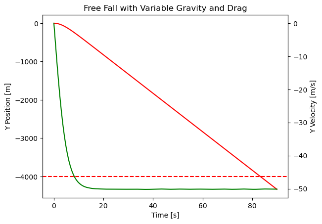

```python
### 3
# Set constants
gamma = 2
span_drag = (0,90)
time_drag = np.linspace(*span_drag,150)

# Calibrate alpha by changing it in small steps and looking at the resulting velocity; land on -50 m/s
alpha = 0.0039

# Solve IVP
soldrag = solve_ivp(fun=fall_grav,t_span=span_drag,y0=y0,t_eval=time_drag)

# Extract time, position, and velocity
soldrag_t = soldrag.t
soldrag_y = soldrag.y[0]
soldrag_vy = soldrag.y[1]

# Create figure and twin x
fig3,ax3a = plt.subplots()
ax3b = ax3a.twinx()

# Plot position, velocity, and bottom of hole
ax3a.plot(soldrag_t,soldrag_y,label='Position',color='red')
ax3b.plot(soldrag_t,soldrag_vy,label='Velocity',color='green')
ax3a.axhline(-4000,color='red',ls='--')

# Label everything
ax3a.set_xlabel('Time [s]')
ax3a.set_ylabel('Y Position [m]')
ax3b.set_ylabel('Y Velocity [m/s]')
ax3a.set_title('Free Fall with Variable Gravity and Drag');
```

Drag greatly lengthens the fall time. The mass can't gain speed forever, so once it hits 50 m/s, it can only fall at 50 m/s after that. Prior models let us reach up to 300 m/s, so this is an exceptional change from that result.

## Part 3: The Coriolis Force

Since the Earth is rotating, there is a Coriolis force on the test mass as it falls. The force can be quite large. For example, imagine the mine shaft is on the Earth's equator and pointed towards the Earth's center. The equator rotates at about half a kilometer per second. So once the test mass has fallen for some time, it will bump into the wall, unless the shaft is very wide. The Coriolis force $\vec{F_c}$ is:

$$ \vec{F_c} = -2m \, \left( \vec{\Omega} \times \vec{v} \right) \tag{3} $$

where $\vec{\Omega}$ is the Earth's rotation rate for a vector along $\hat{z}$ and $m$ is the mass of the object (1 kg for the test mass in this case). For a mine shaft on the equator, we might pick a right-handed coordinate system with the $\hat{x}$ axis along the East, $\hat{y}$ down into the mine shaft, and $\hat{z}$ along the North. This implies the component of the force are:

\begin{equation} F_{c_x} = + 2m \, \Omega v_y \tag{4} \end{equation} \begin{equation} F_{c_y} = - 2m \, \Omega v_x \tag{5} \end{equation} \begin{equation} F_{c_z} = 0 \tag{6} \end{equation}

1. Extend and update your differential equations of motion to include the Coriolis force. You will need to add a Coriolis acceleration term to your equation for the depth coordinate (remember, $F=ma$), and additionally, start tracking the velocity and position in the transverse direction (``side-to-side'' in the shaft).
2. Plot the transverse position of the object as a function of depth, initially assuming $\alpha=0$. That is, both axes will have units of distance. Plot ``dots" every few seconds so that you can see how the particle moves over time. Note that your depth and transverse axes are likely to have very different length scales. The depth will have a range of 4 km, while the transverse direction is about 5m.  
   In your report, this should be **Figure 3**.
3. If the mine shaft is 5m wide, and you drop the test mass from the center, does the test mass reach the bottom? Or does it bump into the wall first?
4. Now turn drag back on. Does drag make any difference here?

```python
### 1
# Create a function that involves the Coriolis Force
def fall_cor(t,s):
    """ A function which calculates the velocity and position of an object using acceleration and velocity functions while assuming a homogeneous variable gravity and
        Coriolis Force

    args:
        t (array): The time when an object is at a certain acceleration and velocity in seconds
        s (array): The velocity and acceleration of an object in m/s and m/s^2 respectively

    Returns:
        array : The resulting position and velocity arrays of the mass in m and m/s respectively
    """
    # s  = [y  vy x  vx]
    # dt = [vy ay vx ax]
    dt = np.zeros(4)
    grav = -1*g*((Re+s[0])/Re)
    dt[0] = s[1]
    dt[1] = grav + alpha*(np.abs(s[1]))**gamma - 2*omega*s[3]
    dt[2] = s[3]
    dt[3] = 2*omega*s[1]
    return dt
```

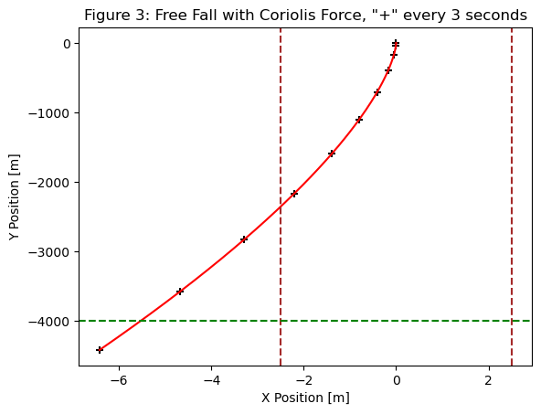

```python
### 2
# Define constants
omega = RR
alpha = 0

# Create analysis time span
time_cor = np.linspace(*span,151)

# Solve IVP
solcor = solve_ivp(fun=fall_cor,t_span=span,y0=s0,t_eval=time_cor)

# Extract time and x y position
solcor_t = solcor.t
solcor_y = solcor.y[0]
solcor_x = solcor.y[2]

# Create figure
fig3,ax3 = plt.subplots()

# Plot mass position
ax3.plot(solcor_x,solcor_y,color='red',label='position')

# Add position marks every 3 seconds
ax3.scatter(solcor_x[::15],solcor_y[::15],color='black',label='position',marker='+')

# Plot hole boundaries
ax3.axvline(-2.5,color='brown',ls='--')  # Left edge of hole
ax3.axvline(2.5,color='brown',ls='--')   # Right edge of hole
ax3.axhline(-4000,color='green',ls='--') # Bottom of hole

# Label everything
ax3.set_xlabel('X Position [m]')
ax3.set_ylabel('Y Position [m]')
ax3.set_title('Figure 3: Free Fall with Coriolis Force, "+" every 3 seconds');
```

3. The mass hits the wall first.

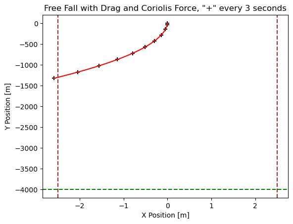

```python
### 4
# Define drag constants
alpha = 0.0039
gamma = 2

# Solve IVP
solcd = solve_ivp(fun=fall_cor,t_span=span,y0=s0,t_eval=time_cor)

# Extract time and x y position
solcd_t = solcd.t
solcd_y = solcd.y[0]
solcd_x = solcd.y[2]

# Set up figure
fig4,ax4 = plt.subplots()

# Plot mass position and markers every 3 seconds
ax4.plot(solcd_x,solcd_y,color='red',label='position')
ax4.scatter(solcd_x[::15],solcd_y[::15],color='black',label='position',marker='+')

# Plot hole boundaries
ax4.axvline(-2.5,color='brown',ls='--')  # Left edge of hole
ax4.axvline(2.5,color='brown',ls='--')   # Right edge of hole
ax4.axhline(-4000,color='green',ls='--') # Bottom of hole

# Label everything
ax4.set_xlabel('X Position [m]')
ax4.set_ylabel('Y Position [m]')
ax4.set_title('Free Fall with Drag and Coriolis Force, "+" every 3 seconds');
```

Within the same timeframe, the mass hits the wall much later since it hits a terminal velocity and cannot fall faster than that.

## Part 4: An infinitely deep mine

Now, let us consider the theoretical case of an infinitely deep mine -- that is, a tunnel which traverses the full diameter of the Earth. For convenience, imagine the tunnel goes from pole-to-pole, such that $\vec{\Omega} \times \vec{v} = 0$, and the Coriolis force can be neglected, as well as the drag force.

Additionally, continue assuming a constant density Earth.

1. Again, plot the depth and velocity as a function of time. (Be careful with the meaning of $y$, as the particle can theoretically traverse fully through to the other side of the Earth.) Comment on what you see in the graph.  
   In your notebook, label this figure clearly as **Figure 4**.
2. How long will it take for the object to reach the other side? At what time does the object reach the center of the Earth, and at what speed?
3. How does this ``crossing-time" compare to the orbital period, where you assume the object is on a circular orbit, in centripetal balance with the attractive force of the gravity. \begin{equation} \frac{v^2}{R} = \frac{GM}{R^2} \tag{7} \end{equation} gives the orbital speed $v$ for a given Earth radius $R$ and Earth mass $M$.

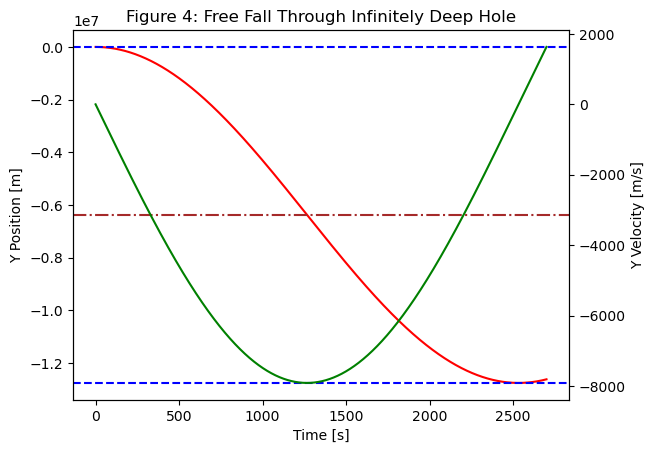

```python
### 1
# Define constants
alpha = 0
D_Earth = Re*2

# Create IVP timeframe
span_inf = (0,2700)
time_inf = np.linspace(*span_inf,10000)

# Solve IVP
solinf = solve_ivp(fun=fall_grav,t_span=span_inf,y0=y0,t_eval=time_inf)

# Extract time, position, and velocity
solinf_t = solinf.t
solinf_y = solinf.y[0]
solinf_vy = solinf.y[1]

# Create figure and twin x
fig5,ax5a = plt.subplots()
ax5b = ax5a.twinx()

# Plot position and velocity
ax5a.plot(solinf_t,solinf_y,color='red',label='position')
ax5b.plot(solinf_t,solinf_vy,color='green',label='velocity')

# Plot surface of earth and center
ax5a.axhline(0,color='blue',ls='--')
ax5a.axhline(-Re,color='brown',ls='-.')
ax5a.axhline(-D_Earth,color='blue',ls='--')

# Label everything
ax5a.set_xlabel('Time [s]')
ax5a.set_ylabel('Y Position [m]')
ax5b.set_ylabel('Y Velocity [m/s]')
ax5a.set_title('Figure 4: Free Fall Through Infinitely Deep Hole');
```

2. The mass falls to the other side of the Earth before turning back around, and the velocity begins to slow down and have positive acceleration at around halfway through the earth

```python
# Define condition to describe mass reaching Earth center
def hit(t,s):
    return s[0]+Re

# Solve IVP
half = solve_ivp(fun=fall_cor,t_span=span_inf,y0=s0,t_eval=time_inf,events=hit)

# Extract time and velocity
t_half = half.t_events[0]
v_half = half.y_events[0]
v_half_print = v_half[0]

print(f'reaches center at time {t_half[0]:.4f} with velocity {v_half_print[1]}')

### 3
# Calculate orbital velocity
orbital = np.sqrt(G*Me/Re)

print(f'The calculated orbital velocity is {orbital:.4f}')
```

```
reaches center at time 1268.9486 with velocity -7855.962583097185
The calculated orbital velocity is 7905.2771
```

## Part 5: A non-uniform Earth

Finally, let us consider the case of a non-uniform Earth, and continue assuming we have no drag. We know from geology that the density increases towards the center. It rises from about 2-3 g/cm$^3$ near the surface, to more like 13 near the center. A simple model for the density $\rho$ as a function of distance from the center of the Earth $r$ is:

$$ \rho(r) = \rho_n \left( 1 - \frac{r^2}{R_{\oplus}^2} \right)^n \tag{8} $$

where $n$ is some exponent, and $\rho_n$ is a normalizing constant. The case of $n=0$ is the constant density Earth, while $n=2$ is closer to the real value. Note that the total mass of the Earth, $M$, must be conserved. Since the mass is the volume integral over the density:

\begin{equation} M = \int_V \rho(r) dV = \int_0^{2\pi} \int_0^{\pi} \int_0^{R_{\oplus}} \rho(r) r^2 \sin \phi \, dr \, d\phi \,d\theta = 4 \pi \int_0^{R_{\oplus}} \rho(r) r^2 \, dr \tag{9} \end{equation}

you will need to recompute the density constant $\rho_n$ for each case of $n>0$, You can use the `quad` integrator for this. Note that the analytic solution is straightforward to do by hand for $n=0$, and still manageable for $n=1,2$. You might consider doing that integral to make sure your method is right, and then you can be confident for $n>0$.

1. Plot the normalized density profile (that is, set $\rho_n=1$) as a function of radius for $n=0, 1, 2, 9$.  
   Put them all on the same plot, with a clear legend.  
   In your notebook, label this figure clearly as **Figure 5**.
2. Now, plot the force profile as a function of radius for $n=0, 1, 2, 9$.  
   This step will show you if your normalization factor $\rho_n$ is correct, because the surface force must be the same for all $n$.  
   In your notebook, label this figure clearly as **Figure 6**.
3. Then, plot the position and velocity as a function of time for $n=0, 1, 2, 9$ as you did in Figure 1/2.  
   In your notebook, label this figure clearly as **Figure 7**.
4. For $n=0, 1, 2, 9$, compute the time to reach the center, and the speed achieved there.

### Part 5, Section A (Density)

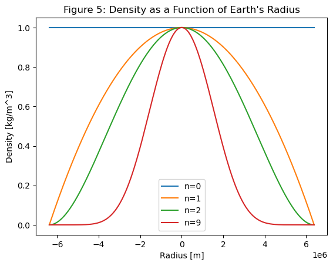

```python
# Write the equation into a function
def density(r,n):
    return p * (1 - r**2/Re**2)**n

# Set constants and radius span
p = 1
rr = np.linspace(Re,-Re,300)

# Create figure
fig6,ax6 = plt.subplots()

# Plot each n=# plot
ax6.plot(rr,density(rr,0),label='n=0')
ax6.plot(rr,density(rr,1),label='n=1')
ax6.plot(rr,density(rr,2),label='n=2')
ax6.plot(rr,density(rr,9),label='n=9')

# Make legend
ax6.legend()

# Label everything
ax6.set_xlabel('Radius [m]')
ax6.set_ylabel('Density [kg/m^3]')
ax6.set_title("Figure 5: Density as a Function of Earth's Radius");
```

### Part 5, Section B (Forces)

```python
# Create function to calculate force
f = lambda r: 4*np.pi * pn * (1 - r**2/Re**2)**n * r**2

# Create holder for the forces over the radius
F0 = np.zeros(len(rr))
F1 = np.zeros(len(rr))
F2 = np.zeros(len(rr))
F9 = np.zeros(len(rr))

# n=0 case
pn,n = 1,0                 # Set n and normalize pn
answ0,err = quad(f,0,Re)   # Integrate
pn0 = Me/answ0             # Calculate density constant (true Earth mass divided by normalized integrated density)
pn = pn0                   # Set constant for integration
for i in range(len(rr)):   # Calculate forces for n=0
    F0[i], err = quad(f, 0, rr[i])

# n=1 case
pn,n = 1,1
answ1,err = quad(f,0,Re)
pn1 = Me/answ1
pn = pn1
for i in range(len(rr)):
    F1[i], err = quad(f, 0, rr[i])

# n=2 case
pn,n = 1,2
answ2,err = quad(f,0,Re)
pn2 = Me/answ2
pn = pn2
for i in range(len(rr)):
    F2[i], err = quad(f, 0, rr[i])

# n=9 case
pn,n = 1,9
answ9,err = quad(f,0,Re)
pn9 = Me/answ9
pn = pn9
for i in range(len(rr)):
    F9[i], err = quad(f, 0, rr[i])
```

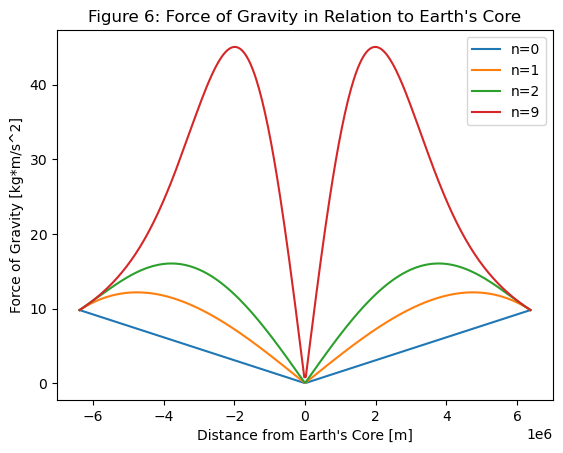

```python
# Create a function to define force due to gravity
def F_g(r,M1):
    return G*M1/r**2

# Create figure
fig7,ax7 = plt.subplots()

# Plot each n case
ax7.plot(rr,np.abs(F_g(rr,F0)),label='n=0')
ax7.plot(rr,np.abs(F_g(rr,F1)),label='n=1')
ax7.plot(rr,np.abs(F_g(rr,F2)),label='n=2')
ax7.plot(rr,np.abs(F_g(rr,F9)),label='n=9')

# Create legend
ax7.legend()

# Label everything
ax7.set_xlabel("Distance from Earth's Core [m]")
ax7.set_ylabel('Force of Gravity [kg*m/s^2]')
ax7.set_title("Figure 6: Force of Gravity in Relation to Earth's Core");
```

### Part 5, Section C (Equations of Motion)

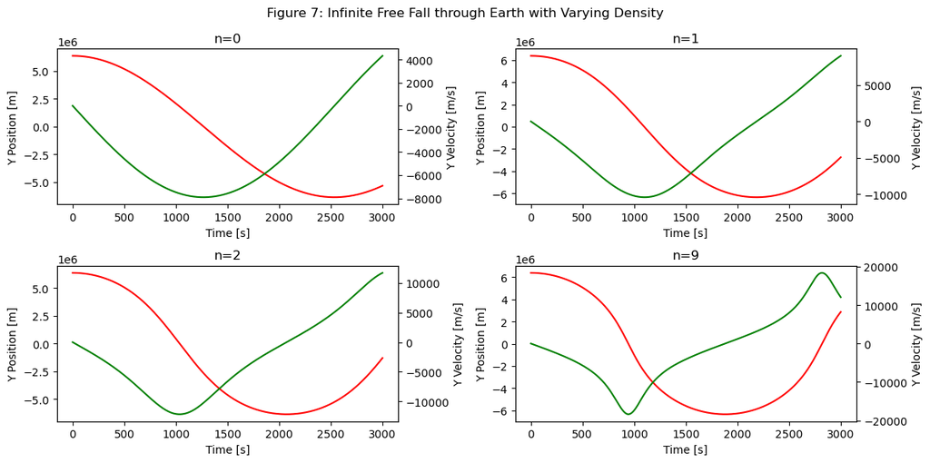

```python
# Create function where force of gravity is a function of density, which is a function of distance from core
def fall_den(t,s):
    # s = [y,vy]
    # dt = [vy,ay]

    dt = np.zeros(2)
    dt[0] = s[1]

    f = lambda r: 4*np.pi * pn * (1 - r**2/Re**2)**n * r**2
    mass,err = quad(f,0,s[0])
    dt[1] = -1*G*mass/s[0]**2
    return dt

# Event requirement for mass reaching earth's center
def hit(t,s):
    return s[0]

# Create time range
span_inf = (0,3000)
time_inf = np.linspace(*span_inf,10000)
Y0 = (Re,0)

# n=0 case
n,pn = 0,pn0                      # Define n and density constant
solden0 = solve_ivp(fun=fall_den,t_span=span_inf,y0=Y0,t_eval=time_inf,events=hit) # Solve IVP
solden0_t = solden0.t         # Extract time
solden0_y = solden0.y[0]      # Extract position
solden0_vy = solden0.y[1]     # Extract velocity

# n=1 case
n,pn = 1,pn1
solden1 = solve_ivp(fun=fall_den,t_span=span_inf,y0=Y0,t_eval=time_inf,events=hit)
solden1_t = solden1.t
solden1_y = solden1.y[0]
solden1_vy = solden1.y[1]

# n=2 case
n,pn = 2,pn2
solden2 = solve_ivp(fun=fall_den,t_span=span_inf,y0=Y0,t_eval=time_inf,events=hit)
solden2_t = solden2.t
solden2_y = solden2.y[0]
solden2_vy = solden2.y[1]

# n=9 case
n,pn = 9,pn9
solden9 = solve_ivp(fun=fall_den,t_span=span_inf,y0=Y0,t_eval=time_inf,events=hit)
solden9_t = solden9.t
solden9_y = solden9.y[0]
solden9_vy = solden9.y[1]

# Create 2x2 figure
fig8,ax8 = plt.subplots(2,2,figsize=(12,6))

# n=0 case
ax8a = ax8[0,0].twinx()                          # Create twin x
ax8[0,0].plot(solden0_t,solden0_y,color='red')   # Plot position
ax8a.plot(solden0_t,solden0_vy,color='green')    # Plot velocity
ax8[0,0].set_xlabel('Time [s]')                  # x label
ax8[0,0].set_ylabel('Y Position [m]')            # pos y label
ax8a.set_ylabel('Y Velocity [m/s]')              # vel y label
ax8[0,0].set_title('n=0')                        # Title

# Plot n=1 case
ax8b = ax8[0,1].twinx()
ax8[0,1].plot(solden1_t,solden1_y,color='red')
ax8b.plot(solden1_t,solden1_vy,color='green')
ax8[0,1].set_xlabel('Time [s]')
ax8[0,1].set_ylabel('Y Position [m]')
ax8b.set_ylabel('Y Velocity [m/s]')
ax8[0,1].set_title('n=1')

# Plot n=2 case
ax8c = ax8[1,0].twinx()
ax8[1,0].plot(solden2_t,solden2_y,color='red')
ax8c.plot(solden2_t,solden2_vy,color='green')
ax8[1,0].set_xlabel('Time [s]')
ax8[1,0].set_ylabel('Y Position [m]')
ax8c.set_ylabel('Y Velocity [m/s]')
ax8[1,0].set_title('n=2')

# Plot n=9 case
ax8d = ax8[1,1].twinx()
ax8[1,1].plot(solden9_t,solden9_y,color='red')
ax8d.plot(solden9_t,solden9_vy,color='green')
ax8[1,1].set_xlabel('Time [s]')
ax8[1,1].set_ylabel('Y Position [m]')
ax8d.set_ylabel('Y Velocity [m/s]')
ax8[1,1].set_title('n=9')

# Title figure
fig8.suptitle('Figure 7: Infinite Free Fall through Earth with Varying Density')

# Fix layout
fig8.tight_layout();
```

```python
### 4
# Extract all times
t_half0 = solden0.t_events[0]
t_half1 = solden1.t_events[0]
t_half2 = solden2.t_events[0]
t_half9 = solden9.t_events[0]

# Extract all velocities
v_half0 = solden0.y_events[0]
v_half1 = solden1.y_events[0]
v_half2 = solden2.y_events[0]
v_half9 = solden9.y_events[0]

print(f'Time = {t_half0[0]:.4f}   Velocity = {v_half0[0,1]:.4f}')
print(f'Time = {t_half1[0]:.4f}   Velocity = {v_half1[0,1]:.4f}')
print(f'Time = {t_half2[0]:.4f}   Velocity = {v_half2[0,1]:.4f}')
print(f'Time =  {t_half9[0]:.4f}   Velocity = {v_half9[0,1]:.4f}')
```

```
Time = 1267.2410   Velocity = -7905.9712
Time = 1096.8915   Velocity = -10435.2388
Time = 1035.1388   Velocity = -12200.7456
Time =  943.8748   Velocity = -18391.9968
```

## Part 6: A Lunar Mine Shaft

Finally, with all of the framework in place, consider the case where the the mine shaft is instead dug on the moon.

1. Compute the travel time to the center of the moon in case we dig a pole-to-pole mine shaft, so that we can again avoid the Coriolis force, though on the moon this force is very small. No drag force either, which is actually realistic for the moon!
2. What is the density (if you asssume a constant density) of the moon compared to that of earth?
3. How does the fall/orbit time depend on density? See if you can discover a relationship between the density and the fall time. You should think beyond strictly linear relationships.

This problem can actually be done on paper, and then you can compare the answer with that for the homogenous earth you did in Part 4.

```python
### 1
# Create a uniform density for the moon
dense = Mm / (4/3*np.pi*Rm**3)

# Make a function to simulate the movement of a mass through an infinite hole
def moon(t,s):
    # s = [y,vy]
    # dt = [vy,ay]
    dt = np.zeros(2)
    dt[0] = s[1]

    mass = dense * 4/3*np.pi*s[0]**3
    g = G*mass/s[0]**2
    dt[1] = -g
    return dt

# Define time span and initial conditions
span_moon = (0,4000)
time_moon = np.linspace(*span_moon,10000)
s0_moon = (Rm,0)

# Solve IVP
solmoon = solve_ivp(fun=moon,t_span=span_moon,y0=s0_moon,t_eval=time_moon,events=hit)

# Extract and print time to center
t_moon = solmoon.t_events[0]
print(f'{t_moon[0]:.4f} seconds to center')
```

```
1624.9060 seconds to center
```

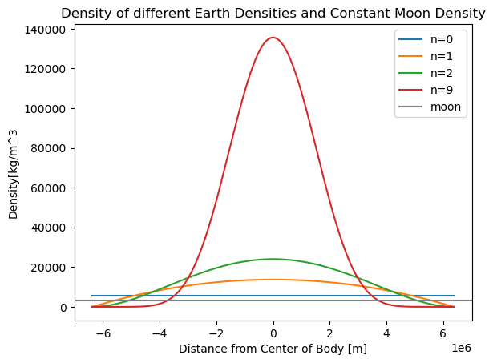

```python
### 2
def density(r,n):
    return p * (1 - r**2/Re**2)**n

p = 1
rr = np.linspace(Re,-Re,300)
rr_moon = np.linspace(Rm,-Rm,300)

fig10,ax10 = plt.subplots()

p = pn0
ax10.plot(rr,density(rr,0),label='n=0')
p = pn1
ax10.plot(rr,density(rr,1),label='n=1')
p = pn2
ax10.plot(rr,density(rr,2),label='n=2')
p = pn9
ax10.plot(rr,density(rr,9),label='n=9')
ax10.axhline(dense, color='grey',label='moon')

ax10.legend()
ax10.set_xlabel('Distance from Center of Body [m]')
ax10.set_ylabel('Density[kg/m^3')
ax10.set_title('Density of different Earth Densities and Constant Moon Density');
```

3. Orbit time depends on the pull of gravity, which depends on the amount of mass a body has. Depending on the distribution of the same mass through the same geometry, an object may fall faster at some points and slower at others, thus changing the orbital period. A body of constant mass will see a different time than one similar to Earth where most of the density is concentrated at the center.

## Part 7: Fourier Transforming Orbits

Take the solutions for n=0 and n=9 of the orbits in Part 5 (the inhomogeneous earth) and Fourier Transform them, to see what frequencies (*1/periods*) are dominant in the power spectra. Comment on what you see.

**Hint:** you could take the orbit from the previous integration in Part 5c, but it is useful to increase the integration time and sampling to get more meaningful smooth enough curves. We discussed this in class.

For an example of a spectral analysis of galactic orbits see https://articles.adsabs.harvard.edu/pdf/1982ApJ...252..308B

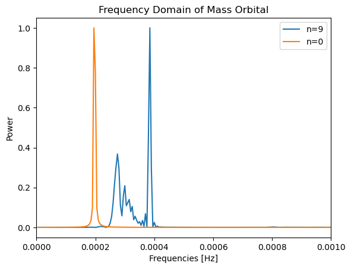

```python
# Define Fourier Transform time
span_FFT = (0,200000)
tlen = 1000000
time_FFT = np.linspace(*span_FFT,tlen)
dt = time_FFT[1]-time_FFT[0]

# Solve IVP both n cases
n,pn = 9,pn9
solFFT9 = solve_ivp(fun=fall_den,t_span=span_FFT,y0=Y0,t_eval=time_FFT)
solFFT9_t = solFFT9.t
solFFT9_y = solFFT9.y[0]
n,pn = 0,pn0
solFFT0 = solve_ivp(fun=fall_den,t_span=span_FFT,y0=Y0,t_eval=time_FFT)
solFFT0_t = solFFT0.t
solFFT0_y = solFFT0.y[0]

# Fourier transform and calculate power
sFFT0 = np.fft.rfft(solFFT0_y)   # Gives FFT array
fFFT0 = np.fft.rfftfreq(tlen,dt) # Give frequency axis
pFFT0 = np.abs(sFFT0)**2         # Calculates power from given Fourier transform
sFFT9 = np.fft.rfft(solFFT9_y)
fFFT9 = np.fft.rfftfreq(tlen,dt)
pFFT9 = np.abs(sFFT9)**2

# Mask out 0
mask9 = fFFT9 > 0
mask0 = fFFT0 > 0

# Create figure
fig11,ax11 = plt.subplots()

# Plot both transforms
ax11.plot(fFFT9[mask9],pFFT9[mask9]/np.max(pFFT9[mask9]),label='n=9')
ax11.plot(fFFT0[mask0],pFFT0[mask0]/np.max(pFFT0[mask0]),label='n=0')

# Set view and make legend
ax11.set_xlim(0,.001)
ax11.legend()

# Label everything
ax11.set_xlabel('Frequencies [Hz]')
ax11.set_ylabel('Power')
ax11.set_title('Frequency Domain of Mass Orbital');
```